# Project 1

### Analysis 5: Two Quantitative Variable

#### Analyst: James Igwenagu

To start off the process I imported the Cars2015.csv file into a variable called cars. The data set appeared, I used the code below to lead the dataset.

```r
cars <- read.csv(file.choose(), header=T)
cars
```

```
##          Make       Model      Type LowPrice HighPrice Drive CityMPG HwyMPG FuelCap Length Width
## 1   Chevrolet       Spark Hatchback   12.270    25.560   FWD      30     39     9.0    145    63
## 2     Hyundai      Accent Hatchback   14.745    17.495   FWD      28     37    11.4    172    67
## 3         Kia         Rio     Sedan   13.990    18.290   FWD      28     36    11.3    172    68
## 4  Mitsubishi      Mirage Hatchback   12.995    15.395   FWD      37     44     9.2    149    66
## 5      Nissan  Versa Note Hatchback   14.180    17.960   FWD      31     40    10.9    164    67
## 6       Dodge        Dart     Sedan   16.495    23.795   FWD      23     35    14.2    184    72
## 7  Chevrolet     Cruze LS     Sedan   16.170    25.660   FWD      24     36    15.6    181    71
## 8        Fiat        500L Hatchback   19.345    24.695   FWD      24     33    13.1    167    70
## 9        Ford       Focus Hatchback   17.170    29.170   FWD      28     38    12.4    179    72
## 10     Toyoto       Yaris Hatchback   14.845    17.629   FWD      30     35    11.1    154    67
## 11      Mazda   2 Touring Hatchback   14.720    17.050   FWD      27     33    11.3    156    68
## 12     Subaru     Impreza     Sedan   18.195    23.295   AWD      27     36    14.5    180    69
## 13 Volkswagon       Jetta     Sedan   16.215    31.120   FWD      25     36    14.5    182    70
## 14      Ford       Fiesta Hatchback   14.455    21.435   FWD      27     37    12.4    174    68
```

[output cut: 88 more lines]

For a pair of quantitative variables, create a scatter plot.

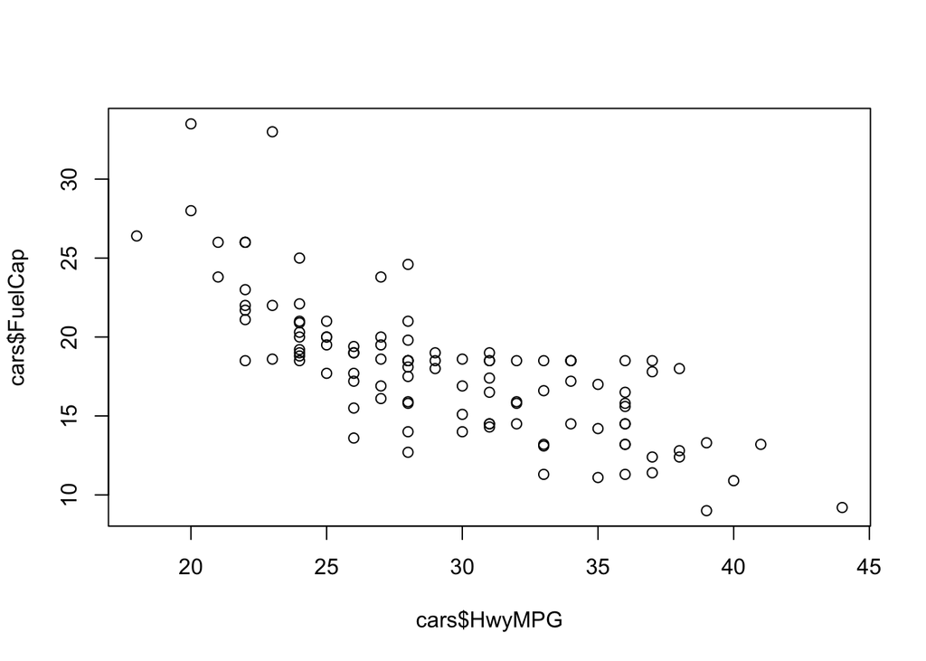

```r
plot(cars$HwyMPG, cars$FuelCap)
```

The variable HwyMPG is the explanatory variable because the HwyMPG predicts change in the response variable which is FuelCap. FuelCap measures the outcome which is the gas tank capacity in gallons depending on the vehicles make and model. Looking at the scatter plot i can determine that the lower the FuelCap the Higher the HwyMPG. Also the higher the FuelCap the lower the HwyMPG is, there is a small number is high FuelCap vehicles. The scatterplot shows a negative potential linear relationship.

## Recommendations

Although we believe that in performing the analysis, we unlocked insights and actual representative data, we don’t believe that any unexpected or unknown information became uncovered through exploring this dataset. For example, we can take a look at the data provided by Analysis #1 and #4; The graphics and summaries show no shocking or unknown information, the smaller the vehicle (By class), the more fuel efficient the vehicle tends to be. Not straying from this opinion, if we take a look at Analysis #2, we can see that the most common type of vehicle, without any hesitation, is a Sedan. The remaining 5 classes make up roughly an equally spread distribution of vehicles on the road. In summary, analyzing this dataset of 2015 Model Years didn’t unlock any additional information we could have not otherwise gathered through our own individual experiences on highways or roads in our respective environments.